# Potential of Minocycline for Treatment of Resistant Hypertension - ScienceDirect

- [View **PDF**](https://www.sciencedirect.com/science/article/pii/S0002914921006330/pdfft?md5=719d8697dc4203e1fde9af2eb3f83307&pid=1-s2.0-S0002914921006330-main.pdf)

## Outline

1. Funding
2. Competing Interest
3. References

## Cited By (2)

## Figures (1)

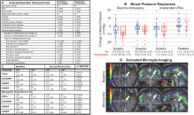

## [The American Journal of Cardiology](https://www.sciencedirect.com/journal/the-american-journal-of-cardiology)

[Volume 156](https://www.sciencedirect.com/journal/the-american-journal-of-cardiology/vol/156/suppl/C), 1 October 2021, Pages 147-149

# Potential of Minocycline for Treatment of Resistant Hypertension

https://doi.org/10.1016/j.amjcard.2021.07.004[Get rights and content](https://s100.copyright.com/AppDispatchServlet?publisherName=ELS&contentID=S0002914921006330&orderBeanReset=true)

Edited by: Dr. W.C. Roberts

Blood pressure (BP) control is suboptimal in many treated hypertensive individuals; up to a quarter have treatment-resistant hypertension (RHTN, uncontrolled BP despite lifestyle modification and 3 antihypertensive drugs at/near maximal tolerated doses).<sup>1</sup> RHTN conveys a high risk for adverse events. Exploring novel concepts and mechanisms could accelerate identification of new management targets. Our studies, primarily with rodent models of human hypertension, inform our hypothesis of a *dysfunctional brain-gut communication*.<sup>2</sup> Our overarching postulate indicates that prohypertensive signals (stress, inactivity, etc.) increase sympathetic and dampen parasympathetic drives, sequentially leading to gut dysbiosis, leakiness, and pathology. These actions alter plasma metabolic and immune profiles important in neuroinflammation, increase BP, and perpetuate high BP leading to RHTN. Thus, neuroinflammation and dysbiosis are critical in RHTN.<sup>3</sup> Minocycline, an anti-inflammatory antibiotic, crosses the blood-brain barrier and reduces BP in animal HTN models.<sup>4</sup><sup>,</sup><sup>5</sup> Accordingly we tested our hypothesis in a pilot study of RHTN patients.

The IRB-approved study was conducted in ambulatory RHTN patients with documented cardiovascular disease (CVD) and/or type-2 diabetes, and all subjects provided voluntary written informed consent. Briefly, high-risk adults with RHTN receiving stable-dose antihypertensive medications for >3 months were enrolled. Age >85 years, orthostatic hypotension, or contraindications to tetracyclines were exclusions. A dose-finding (100 mg *vs* 200 mg bid) open-label study was planned to determine the lowest minocycline dose to reduce mean daytime ambulatory systolic BP (dAMBP) ≥5 mmHg (“Responder”) (Study 1, ClinicalTrials.gov NCT02133872), followed by a placebo-controlled, double-blind, cross-over trial at that dose and assessment of activated microglia in brain autonomic regions by PET<sup>6</sup> (Study 2, ClinicalTrials.gov NCT02133885). However, an early patient initially receiving 200 mg bid reported lightheadedness/dizziness with a BP 88/50 mmHg, which drove protocol modification for the safety of these high-risk patients to an open-label dose-finding effort beginning at 50 mg bid, escalating to 100 and 200 mg bid in nonresponsive subjects.

We recruited 40 patients; 14 either failed screening or withdrew (primarily after dissatisfaction with ambulatory BP monitoring [ABPM]), and baseline characteristics of the remaining 26 are summarized (Figure A). All patients were taking ≥3 antihypertensive medications and, because they were high risk, it was not possible (nor ethical) to withdraw antihypertensive drugs. At visit 1, participants had unattended automated office BP (Office) measured three times (Omron HEM-907XL), were instructed in measuring home BP thrice weekly, and were fitted for 24-hour ABPM (Spacelabs 90207). At visit 2, minocycline was initiated with follow-up every 2-4 weeks. Visits 4, 8, and 12 included ABPM. Participation ended upon achievement of a decline in mean systolic dAMBP of ≥5 mmHg (“Responders”). Visits 5 and 9 were by phone, reminding patients to return for titration or continue minocycline and return for a final visit. Dose titrations occurred at visits 6 (100 mg bid) and 10 (200 mg bid) if target dAMBP was not achieved. Pill counts assessed minocycline adherence; patients were queried about antihypertensive medications and adverse effects.

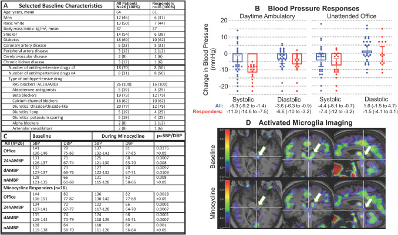

Since Th17 cells are implicated in trans-endothelial/epithelial migration among disorders involving gut inflammation<sup>7</sup>, we enumerated circulating CD4<sup>+</sup> inflammatory cells containing CD161<sup>+</sup> IL17<sup>+</sup> and CCR6<sup>+</sup> ITGb7<sup>+</sup>CD161<sup>+</sup> IL17<sup>+</sup> markers (flow cytometry, 9 patients). These subfractions declined significantly during minocycline [-20% (-40 to-0.1) and -3.4% (-6.5 to -0.3), respectively] in responders. Minocycline was associated with reduced BP and decreased active microglia<sup>5</sup> in a responder (Figure D).

This is the first reported human trial investigating whether minocycline mitigates impaired brain-gut communication associated with RHTN via anti-inflammatory properties. These results extend our findings from animal models.<sup>4</sup><sup>,</sup><sup>5</sup> Minocycline has anti-inflammatory properties, penetrates the blood-brain barrier, and inhibits microglia activation and neuroinflammation. Our evidence from experimental animals documents minocycline's antihypertensive effects are likely mediated by anti-inflammatory action inhibiting brain microglia activation. Data here support this contention in RHTN as the dose (50 mg bid) was not likely high enough to be an effective antibiotic, thus, it would be expected to show little effect on microbiome diversity. However, a dysfunctional brain-gut axis mediated by impaired autonomic regulation of gut function and its microbiome cannot be excluded. This is particularly relevant since autonomic dysregulation is associated with gut dysbiosis in neurological diseases and now also in RHTN.

This first-in-human pilot trial provides important information to support a mechanism-based, larger, randomized, placebo-controlled clinical trial to establish minocycline or a modified tetracycline derivative as a therapeutic option for RHTN.

## Funding

Supported by NIH/NHLBI 1R01HL33610, 1RO1HL132448; the Gatorade Foundation through the University of Florida Department of Medicine; and the University of Florida College of Medicine and College of Pharmacy.

## Competing Interest

The authors declare no financial interests/personal relationships which may be considered as potential competing interests.

## References

**1**

RM Carey, DA Calhoun, GL Bakris, RD Brook, SL Daugherty, CR Dennison-Himmelfarb, BM Egan, JM Flack, SS Gidding, E Judd, DT Lackland, CL Laffer, C Newton-Cheh, SM Smith, SJ Taler, SC Textor, TN Turan, WB White

**American Heart Association Professional/Public Education and Publications Committee of the Council on Hypertension; Council on Cardiovascular and Stroke Nursing; Council on Clinical Cardiology; Council on Genomic and Precision Medicine; Council on Peripheral Vascular Disease; Council on Quality of Care and Outcomes Research; and Stroke Council. Resistant hypertension: detection, evaluation, and management: a Scientific Statement from the American Heart Association**

Hypertension, 72 (2018), pp. e53-e90, 10.1161/HYP.0000000000000084

Google Scholar

**2**

J Zubcevic, EM Richards, T Yang, S Kim, C Sumners, CJ Pepine, MK Raizada

**Impaired autonomic nervous system-microbiome circuit in hypertension**

Circ Res, 125 (2019), pp. 104-116, 10.1161/CIRCRESAHA.119.313965

[View Record in Scopus](https://www.scopus.com/inward/record.url?eid=2-s2.0-85068490895&partnerID=10&rel=R3.0.0)Google Scholar

**3**

MM Santisteban, S Kim, CJ Pepine, MK Raizada

**Brain-gut-bone marrow axis: implications for hypertension and related therapeutics**

Circ Res, 118 (2016), pp. 1327-1336, 10.1161/CIRCRESAHA.116.307709

[View Record in Scopus](https://www.scopus.com/inward/record.url?eid=2-s2.0-84963838320&partnerID=10&rel=R3.0.0)Google Scholar

**4**

T Yang, EM Richards, CJ Pepine, MK Raizada

**The gut microbiota and the brain-gut-kidney axis in hypertension and chronic kidney disease**

Nat Rev Nephrol, 14 (2018), pp. 442-456, 10.1038/s41581-018-0018-2

[View Record in Scopus](https://www.scopus.com/inward/record.url?eid=2-s2.0-85046905840&partnerID=10&rel=R3.0.0)Google Scholar

**5**

T Yang, MM Santisteban, V Rodriguez, E Li, N Ahmari, JM Carvajal, M Zadeh, M Gong, Y Qi, J Zubcevic, B Sahay, CJ Pepine, MK Raizada, M Mohamadzadeh

**Gut dysbiosis is linked to hypertension**

Hypertension, 65 (2015), pp. 1331-1340, 10.1161/HYPERTENSIONAHA.115.05315

[View Record in Scopus](https://www.scopus.com/inward/record.url?eid=2-s2.0-84937549863&partnerID=10&rel=R3.0.0)Google Scholar

**6**

T Funck, K Larcher, PJ Toussaint, AC Evans, A Thiel

**APPIAN: Automated Pipeline for PET Image Analysis**

Front Neuroinform, 12 (2018), p. 64, 10.3389/fninf.2018.00064

[View Record in Scopus](https://www.scopus.com/inward/record.url?eid=2-s2.0-85054790893&partnerID=10&rel=R3.0.0)Google Scholar

**7**

S Kim, R Goel, A Kumar, Y Qi, G Lobaton, K Hosaka, M Mohammed, EM Handberg, EM Richards, CJ Pepine, MK Raizada

**Imbalance of gut microbiome and intestinal epithelial barrier dysfunction in patients with high blood pressure**

Clin Sci (Lond), 132 (2018), pp. 701-718, 10.1042/CS20180087

[View Record in Scopus](https://www.scopus.com/inward/record.url?eid=2-s2.0-85046541059&partnerID=10&rel=R3.0.0)Google Scholar

### Minocycline Reduces Hypothalamic Microglia Activation and Improves Metabolic Dysfunction in High Fat Diet-Induced Obese Mice

- 2022, Frontiers in Physiology

### Gut Microbiome and Neuroinflammation in Hypertension

- 2022, Circulation Research

[View Abstract](https://www.sciencedirect.com/science/article/abs/pii/S0002914921006330)

© 2021 Elsevier Inc. All rights reserved.

  [Download PDF](https://www.sciencedirect.com/science/article/pii/S0002914921006287/pdfft?md5=19276269c6b011e8c7c716bb10637e53&pid=1-s2.0-S0002914921006287-main.pdf)

- The American Journal of Cardiology, Volume 156, 2021, pp. 1-8

  [Download PDF](https://www.sciencedirect.com/science/article/pii/S0002914921006263/pdfft?md5=58f0a9e9909be1e2c671c28eadb4c7ee&pid=1-s2.0-S0002914921006263-main.pdf)

- The American Journal of Cardiology, Volume 156, 2021, pp. 32-38

  [Download PDF](https://www.sciencedirect.com/science/article/pii/S0002914921006275/pdfft?md5=e97b22cc76ad973bbe6fcdd5769a34ca&pid=1-s2.0-S0002914921006275-main.pdf)

- Citation Indexes: 2

Captures

- Readers: 4

[View details](https://plu.mx/plum/a/?doi=10.1016/j.amjcard.2021.07.004&theme=plum-sciencedirect-theme&hideUsage=true)